# Introduction to R

The workshop team

May 27 2022

## Content

- about R and RStudio
- data handling: importing and accessing data manipulation and analysis
- visualisation

# About R and RStudio

[figure not shown]

- **R**: free software environment for statistical computing and graphics
- **RStudio**: GUI/ integrated development environment (IDE) for R

## R help & the comunity

- Stackoverflow
- `man` pages and examples
- cheat sheets

[figure not shown]

## Goals and purposes with using R

- powerful, flexible/customisable
- easy to develop complex analyses
- **reproducible science**: scripts and markdowns

## Scripts and markdowns

Markup languages (HTML, LaTeX, markdown) are used to format text. Both exercises and presentations during this lab have been produced using the rmarkdown package. The code for these are available in the files Intro_to_R.Rmd and Intro_to_R_EXERCISE.Rmd. For longer-form writing, including reports and papers, check out the bookdown package.

[figure not shown]

## Data handling: collecting and organisation

**Conventions about data format**

- Observations are entered in **rows**
- Variables are entered in **columns**
- A column of data should contain only one data type

## Data handling: collecting and organisation

**Best practice**

- Store a copy of data in nonproprietary formats
- Leave an uncorrected file when doing analyses
- Maintain effective metadata about the data
- Create folders for relevant task to keep the overview over your analyses

## Error messages

- Warnings can be ignored.
- Specific hint? e.g.
  - wrong data format, characters/factors instead of numbers
  - library not loaded, package not installed
- Try running example code, and check the example input
- Google is your friend

# Getting started: Connecting to the R server

In you own computer’s browser, open a new tab and type

`<AMI address>:8787`

in the URL bar.

username: evomics

password: genomics2022

- open RStudio
- open a script
- start typing/ working …

## How R works: Operators & Functions

- Arithmetic (basic math): `+`, `-`, `*`, `/`, `^`, …
- Relational: `<`, `>`, `==`, `!=`
- Logical: `!`, `&`,`&&`, `|`, `||`, `TRUE`, `FALSE`
- Assignment: `<-`, `=`
- Pipe: `%>%`
- Specifying ranges (colon): `:`
- Access library functions: `::`
- Comment: `#`
- Functions: e.g. `c()`, `sum()`, `ggplot()`, …
- Tilde operator (specify models, functions): `~`

## How R works: Operators

Examples: Arithmetic (basic math): +, -, *, /, ^, …

```r
12+13+14
```

```
## [1] 39
```

```r
(5+2)*2
```

```
## [1] 14
```

```r
12^2
```

```
## [1] 144
```

## How R works: Operators & Functions

**Assignment (<-, =)**

```r
x <- 12
y <- 13
z <- 14
x
```

```
## [1] 12
```

```r
x+y+z
```

```
## [1] 39
```

## How R works: Operators & Functions

function(data, additional arguments)

```r
sum(12,13,14)
```

```
## [1] 39
```

```r
sum(x, y, z)
```

```
## [1] 39
```

```r
k <- c(12, 13, 14)
k
```

```
## [1] 12 13 14
```

```r
sum(k)
```

```
## [1] 39
```

# How to access and modify parts of data structures

- How to access parts in **vectors**,tables and **S4 objects**
- How to work with tables (**data frame**/**data table**/**tibble**/**matrix**)

## How to access and modify parts of data structures: vectors

vector[element_number], length(vector)

```r
k
```

```
## [1] 12 13 14
```

```r
k[2]
```

```
## [1] 13
```

```r
length(k)
```

```
## [1] 3
```

```r
(k[4] <- 15)
```

```
## [1] 15
```

```r
length(k)
```

```
## [1] 4
```

## How to access and modify parts of data structures: vectors

vector[element], length(vector)

```r
2:4
```

```
## [1] 2 3 4
```

```r
3:4
```

```
## [1] 3 4
```

```r
animals <- c("platypus", "nudibranch", "potoo", "peacock mantis shrimp")
animals[3:4]
```

```
## [1] "potoo"                 "peacock mantis shrimp"
```

## How to access and modify parts of data structures: tables

table[rows, columns], table$column_name, dim(table)

```r
df <- tibble(k, animals, colour=c("brown", "rainbow", "brown", "rainbow"))
df
```

```
## # A tibble: 4 × 3
##       k animals               colour
##   <dbl> <chr>                 <chr>
## 1    12 platypus              brown
## 2    13 nudibranch            rainbow
## 3    14 potoo                 brown
## 4    15 peacock mantis shrimp rainbow
```

```r
df$colour
```

```
## [1] "brown"   "rainbow" "brown"   "rainbow"
```

## How to access and modify parts of data structures: tables

table$column, table[rows, columns], dim(table)

```r
dim(df)
```

```
## [1] 4 3
```

```r
df[1:2,]
```

```
## # A tibble: 2 × 3
##       k animals    colour
##   <dbl> <chr>      <chr>
## 1    12 platypus   brown
## 2    13 nudibranch rainbow
```

```r
df[df$colour=="brown",] #select rows that match a condition
```

```
## # A tibble: 2 × 3
##       k animals  colour
##   <dbl> <chr>    <chr>
## 1    12 platypus brown
## 2    14 potoo    brown
```

## S4 object (Specifically defined tables or more complex data structures)

S4 objects can do a bunch of interesting things, Josie will talk more about these later. Use `@` to access S4 object slots (similar to using `$` for other objects)

```r
dnastring <-  Biostrings::DNAString("TTGAAA-CTC-N")
str(dnastring)
```

```
## Formal class 'DNAString' [package "Biostrings"] with 5 slots
##   ..@ shared         :Formal class 'SharedRaw' [package "XVector"] with 2 slots
##   .. .. ..@ xp                    :<externalptr>
##   .. .. ..@ .link_to_cached_object:<environment: 0x556a25360208>
##   ..@ offset         : int 0
##   ..@ length         : int 12
##   ..@ elementMetadata: NULL
##   ..@ metadata       : list()
```

```r
dnastring@length
```

```
## [1] 12
```

## Functions to start with: Importing data and inspecting it

```r
# Working directory: setwd(), getwd()
setwd("~/Path/to/working_directory")
getwd()

# tidyverse
data <- read_delim("file.csv")
data <- read_tsv("file.tsv")
data <- read_csv("file.csv")
# base R: read.csv()
data <- read.csv("~/Path/to/file.csv", header=TRUE, sep = ",")

# inspect the data structure
head(data)
tail(data)
dim(data)
str(data)
rownames(data)
colnames(data)
view(data)
```

# Working with tables (data frame, tibble, data table)

```r
#library(tidyverse)
mpg # data set included in ggplot2 package
```

```
## # A tibble: 234 × 11
##    manufacturer model      displ  year   cyl trans drv     cty   hwy fl    class
##    <chr>        <chr>      <dbl> <int> <int> <chr> <chr> <int> <int> <chr> <chr>
##  1 audi         a4           1.8  1999     4 auto… f        18    29 p     comp…
##  2 audi         a4           1.8  1999     4 manu… f        21    29 p     comp…
##  3 audi         a4           2    2008     4 manu… f        20    31 p     comp…
##  4 audi         a4           2    2008     4 auto… f        21    30 p     comp…
##  5 audi         a4           2.8  1999     6 auto… f        16    26 p     comp…
##  6 audi         a4           2.8  1999     6 manu… f        18    26 p     comp…
##  7 audi         a4           3.1  2008     6 auto… f        18    27 p     comp…
##  8 audi         a4 quattro   1.8  1999     4 manu… 4        18    26 p     comp…
##  9 audi         a4 quattro   1.8  1999     4 auto… 4        16    25 p     comp…
## 10 audi         a4 quattro   2    2008     4 manu… 4        20    28 p     comp…
## # … with 224 more rows
```

## Working with tables

```r
mpg %>%
  filter(manufacturer=="lincoln")
```

```
## # A tibble: 3 × 11
##   manufacturer model       displ  year   cyl trans drv     cty   hwy fl    class
##   <chr>        <chr>       <dbl> <int> <int> <chr> <chr> <int> <int> <chr> <chr>
## 1 lincoln      navigator …   5.4  1999     8 auto… r        11    17 r     suv
## 2 lincoln      navigator …   5.4  1999     8 auto… r        11    16 p     suv
## 3 lincoln      navigator …   5.4  2008     8 auto… r        12    18 r     suv
```

```r
mpg %>%
  select(-c(displ,year,cyl,trans,drv,fl,class))
```

```
## # A tibble: 234 × 4
##    manufacturer model        cty   hwy
##    <chr>        <chr>      <int> <int>
##  1 audi         a4            18    29
##  2 audi         a4            21    29
##  3 audi         a4            20    31
##  4 audi         a4            21    30
##  5 audi         a4            16    26
##  6 audi         a4            18    26
##  7 audi         a4            18    27
##  8 audi         a4 quattro    18    26
##  9 audi         a4 quattro    16    25
## 10 audi         a4 quattro    20    28
## # … with 224 more rows
```

## Working with tables

```r
mpg %>%
  dplyr::rename(fuel=fl) %>%
  head(n=2)
```

```
## # A tibble: 2 × 11
##   manufacturer model displ  year   cyl trans      drv     cty   hwy fuel  class
##   <chr>        <chr> <dbl> <int> <int> <chr>      <chr> <int> <int> <chr> <chr>
## 1 audi         a4      1.8  1999     4 auto(l5)   f        18    29 p     compa…
## 2 audi         a4      1.8  1999     4 manual(m5) f        21    29 p     compa…
```

```r
mpg %>%
  mutate(city_kmL=cty/2.352) %>%
  select(c(manufacturer, model, displ, year, city_kmL))
```

```
## # A tibble: 234 × 5
##    manufacturer model      displ  year city_kmL
##    <chr>        <chr>      <dbl> <int>    <dbl>
##  1 audi         a4           1.8  1999     7.65
##  2 audi         a4           1.8  1999     8.93
##  3 audi         a4           2    2008     8.50
##  4 audi         a4           2    2008     8.93
##  5 audi         a4           2.8  1999     6.80
##  6 audi         a4           2.8  1999     7.65
##  7 audi         a4           3.1  2008     7.65
##  8 audi         a4 quattro   1.8  1999     7.65
##  9 audi         a4 quattro   1.8  1999     6.80
## 10 audi         a4 quattro   2    2008     8.50
## # … with 224 more rows
```

## Working with tables

```r
# median(), sd(), IQR(), min(), max(), n()
summary <- mpg %>%
  summarise(mean_fuel = mean(cty))
summary
```

```
## # A tibble: 1 × 1
##   mean_fuel
##       <dbl>
## 1      16.9
```

## Working with tables

```r
mpg %>%
  pivot_longer(c(cty, hwy), names_to="city_highway", values_to="mpg") %>%
  select(manufacturer, model, year, trans, city_highway, mpg)
```

```
## # A tibble: 468 × 6
##    manufacturer model  year trans      city_highway   mpg
##    <chr>        <chr> <int> <chr>      <chr>        <int>
##  1 audi         a4     1999 auto(l5)   cty             18
##  2 audi         a4     1999 auto(l5)   hwy             29
##  3 audi         a4     1999 manual(m5) cty             21
##  4 audi         a4     1999 manual(m5) hwy             29
##  5 audi         a4     2008 manual(m6) cty             20
##  6 audi         a4     2008 manual(m6) hwy             31
##  7 audi         a4     2008 auto(av)   cty             21
##  8 audi         a4     2008 auto(av)   hwy             30
##  9 audi         a4     1999 auto(l5)   cty             16
## 10 audi         a4     1999 auto(l5)   hwy             26
## # … with 458 more rows
```

## Working with tables

```r
mpg %>%
  pivot_longer(c(cty, hwy), names_to="city_highway", values_to="mpg") %>%
  summarise(mean_fuel = mean(mpg))
```

```
## # A tibble: 1 × 1
##   mean_fuel
##       <dbl>
## 1      20.1
```

## Working with tables

```r
car_origins <- tibble(
  manufacturer=c("audi", "chevrolet", "dodge", "ford", "honda", "hyundai", "jeep", "land rover", "lincoln", "mercury", "nissan", "pontiac", "subaru", "toyota", "volkswagen"),
  country_origin=c("Germany", "USA", "USA", "USA", "Japan", "South Korea", "USA", "USA", "USA", "USA", "Japan", "USA","Japan", "Japan", "Germany"))
head(car_origins, n=3)
```

```
## # A tibble: 3 × 2
##   manufacturer country_origin
##   <chr>        <chr>
## 1 audi         Germany
## 2 chevrolet    USA
## 3 dodge        USA
```

```r
mpg %>%
  left_join(car_origins) %>%
  select(c(manufacturer, model, year, trans, country_origin))
```

```
## # A tibble: 234 × 5
##    manufacturer model       year trans      country_origin
##    <chr>        <chr>      <int> <chr>      <chr>
##  1 audi         a4          1999 auto(l5)   Germany
##  2 audi         a4          1999 manual(m5) Germany
##  3 audi         a4          2008 manual(m6) Germany
##  4 audi         a4          2008 auto(av)   Germany
##  5 audi         a4          1999 auto(l5)   Germany
##  6 audi         a4          1999 manual(m5) Germany
##  7 audi         a4          2008 auto(av)   Germany
##  8 audi         a4 quattro  1999 manual(m5) Germany
##  9 audi         a4 quattro  1999 auto(l5)   Germany
## 10 audi         a4 quattro  2008 manual(m6) Germany
## # … with 224 more rows
```

## Working with tables

```r
mpg %>%
  summarise(mean_fuel = mean(cty))
```

```
## # A tibble: 1 × 1
##   mean_fuel
##       <dbl>
## 1      16.9
```

```r
mean(mpg$cty)
```

```
## [1] 16.85897
```

## BREAK for the first part of the exercise

# Data visalisation with ggplot2

ggplot(table, aes(x=column1, y=column2))+geom_…()

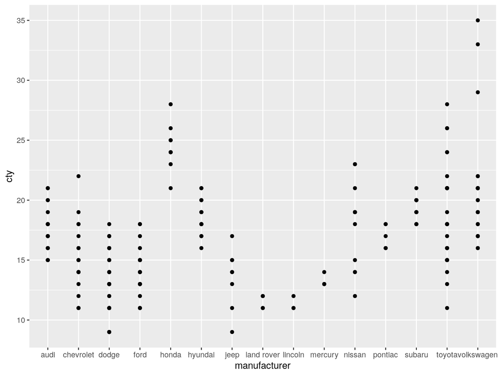

```r
ggplot(mpg, aes(x=manufacturer, y=cty))+geom_point()
```

## Data visualisation with ggplot2

*What kind of “geom” to use?*

Check out the [R graph gallery](https://r-graph-gallery.com/)!

*How about colours?*

Try out different colour palettes inspired from [Wes Anderson movies](https://github.com/karthik/wesanderson) or [Studio Ghibli](https://github.com/ewenme/ghibli). Or find good colour combinations [here](https://medialab.github.io/iwanthue/) and specify them manually.

*Easy professional styles?*

Explore different styles from the ggthemes package last_plot()+theme_

*Feel silly?*

https://cran.r-project.org/web/packages/xkcd/vignettes/xkcd-intro.pdf